# Table of Content

## 4.4 Feature Engineering on Categorical Data

- First, encoding all categorical data by using one hot encoding;
- Then Use stepwise selection to remove unnessary features;

```python
#Now, let's encoding all the categorical variables in trainning data set:

X_train = X_train.reset_index(drop=True)

def label_encoder(df,column):
    le=preprocessing.LabelEncoder()
    le.fit_transform(df[column])
    ohe = preprocessing.OneHotEncoder()
    temp_array= ohe.fit_transform(df[[column]]).toarray()
    column_names = [column+"_"+str(m) for m in le.classes_]
    return(pd.DataFrame(temp_array,columns=column_names))

numerical_variables = [col for col in X_train.columns
                       if X_train[col].dtype in ['int64', 'float64','uint8','int32']]

print(numerical_variables)

categorical_variables = [col for col in X_train.columns
                         if X_train[col].dtype not in ['int64', 'float64','uint8','int32']]

print(categorical_variables)

new_X_train = X_train[numerical_variables]

for column in categorical_variables:
    new_X_train = pd.concat([new_X_train,label_encoder(X_train,column)],axis=1)

new_X_train.columns
```

```
['age', 'campaign', 'pdays', 'previous', 'cons.price.idx', 'cons.conf.idx', 'nr.employed', 'pdays_in']
['job', 'marital', 'education', 'default', 'housing', 'loan', 'contact', 'month', 'day_of_week', 'poutcome']
```

```
Index(['age', 'campaign', 'pdays', 'previous', 'cons.price.idx', 'cons.conf.idx', 'nr.employed', 'pdays_in', 'job_admin.', 'job_blue-collar', 'job_entrepreneur', 'job_housemaid', 'job_management', 'job_retired', 'job_self-employed', 'job_services', 'job_student', 'job_technician', 'job_unemployed', …
       'poutcome_failure', 'poutcome_nonexistent', 'poutcome_success'],
      dtype='object')
```

```python
print(new_X_train.shape)
print(new_X_train.dtypes)
```

```
(28823, 61)
age                                int64
campaign                           int64
pdays                              int64
previous                           int64
cons.price.idx                   float64
cons.conf.idx                    float64
nr.employed                      float64
pdays_in                           int32
job_admin.                       float64
job_blue-collar                  float64
job_entrepreneur                 float64
job_housemaid                    float64
job_management                   float64
job_retired                      float64
job_self-employed                float64
job_services                     float64
job_student                      float64
job_technician                   float64
job_unemployed                   float64
job_unknown                      float64
marital_divorced                 float64
marital_married                  float64
marital_single                   float64
marital_unknown                  float64
education_basic.4y               float64
education_basic.6y               float64
education_basic.9y               float64
education_high.school            float64
education_illiterate             float64
education_professional.course    float64
education_university.degree      float64
education_unknown                float64
default_no                       float64
default_unknown                  float64
default_yes                      float64
housing_no                       float64
housing_unknown                  float64
housing_yes                      float64
loan_no                          float64
```

[output cut: 8 more lines]

```
month_jun                        float64
month_mar                        float64
month_may                        float64
month_nov                        float64
month_oct                        float64
month_sep                        float64
day_of_week_fri                  float64
day_of_week_mon                  float64
day_of_week_thu                  float64
day_of_week_tue                  float64
day_of_week_wed                  float64
poutcome_failure                 float64
poutcome_nonexistent             float64
poutcome_success                 float64
dtype: object
```

```python
y_train = list(y_train)
# stepwise selection to remove unnessary features: (running times: about 1 minute)
def stepwise_selection(data, target,SL_in=0.05,SL_out = 0.05):
    initial_features = data.columns.tolist()
    best_features = []
    while (len(initial_features)>0):
        remaining_features = list(set(initial_features)-set(best_features))
        new_pval = pd.Series(index=remaining_features)
        for new_column in remaining_features:
            model = sm.OLS(target, sm.add_constant(data[best_features+[new_column]])).fit()
            new_pval[new_column] = model.pvalues[new_column]
        min_p_value = new_pval.min()
        if(min_p_value<SL_in):
            best_features.append(new_pval.idxmin())
            while(len(best_features)>0):
                best_features_with_constant = sm.add_constant(data[best_features])
                p_values = sm.OLS(target, best_features_with_constant).fit().pvalues[1:]
                max_p_value = p_values.max()
                if(max_p_value >= SL_out):
                    excluded_feature = p_values.idxmax()
                    best_features.remove(excluded_feature)
                else:
                    break
        else:
            break
    return best_features
best_features = stepwise_selection(new_X_train,y_train)
print(best_features)
```

```
['previous', 'pdays', 'nr.employed', 'month_may', 'cons.conf.idx', 'month_mar', 'month_jul', 'cons.price.idx', 'contact_telephone', 'contact_cellular', 'day_of_week_mon', 'month_sep', 'month_jun', 'month_dec', 'campaign', 'default_no', 'job_retired', 'poutcome_failure', 'education_university.degree'…
```

```python
#drop unnessary features in trainning data set:
selected_X_train = new_X_train.drop(columns=[col for col in new_X_train
                                             if col not in best_features])
```

```python
#Based on the results on the trainning dataset,
#let's encoding all the categorical variables and drop all necessary features in the test data set
X_test = X_test.reset_index(drop=True)


def label_encoder(df,column):
    le=preprocessing.LabelEncoder()
    le.fit_transform(df[column])
    ohe = preprocessing.OneHotEncoder()
    temp_array= ohe.fit_transform(df[[column]]).toarray()
    column_names = [column+"_"+str(m) for m in le.classes_]
    return(pd.DataFrame(temp_array,columns=column_names))

numerical_variables = [col for col in X_test.columns
                       if X_test[col].dtype in ['int64', 'float64','uint8','int32']]

print(numerical_variables)

categorical_variables = [col for col in X_test.columns
                         if X_test[col].dtype not in ['int64', 'float64','uint8','int32']]
print(categorical_variables)

new_X_test = X_test[numerical_variables]

for column in categorical_variables:
    new_X_test = pd.concat([new_X_test,label_encoder(X_test,column)],axis=1)

new_X_test.columns
```

```
['age', 'campaign', 'pdays', 'previous', 'cons.price.idx', 'cons.conf.idx', 'nr.employed', 'pdays_in']
['job', 'marital', 'education', 'default', 'housing', 'loan', 'contact', 'month', 'day_of_week', 'poutcome']
```

```
Index(['age', 'campaign', 'pdays', 'previous', 'cons.price.idx', 'cons.conf.idx', 'nr.employed', 'pdays_in', 'job_admin.', 'job_blue-collar', 'job_entrepreneur', 'job_housemaid', 'job_management', 'job_retired', 'job_self-employed', 'job_services', 'job_student', 'job_technician', 'job_unemployed', …
       'poutcome_failure', 'poutcome_nonexistent', 'poutcome_success'],
      dtype='object')
```

```python
print(new_X_test.shape)
print(new_X_test.dtypes)
y_test = list(y_test)
```

```
(12353, 61)
age                                int64
campaign                           int64
pdays                              int64
previous                           int64
cons.price.idx                   float64
cons.conf.idx                    float64
nr.employed                      float64
pdays_in                           int32
job_admin.                       float64
job_blue-collar                  float64
job_entrepreneur                 float64
job_housemaid                    float64
job_management                   float64
job_retired                      float64
job_self-employed                float64
job_services                     float64
job_student                      float64
job_technician                   float64
job_unemployed                   float64
job_unknown                      float64
marital_divorced                 float64
marital_married                  float64
marital_single                   float64
marital_unknown                  float64
education_basic.4y               float64
education_basic.6y               float64
education_basic.9y               float64
education_high.school            float64
education_illiterate             float64
education_professional.course    float64
education_university.degree      float64
education_unknown                float64
default_no                       float64
default_unknown                  float64
default_yes                      float64
housing_no                       float64
housing_unknown                  float64
housing_yes                      float64
loan_no                          float64
```

[output cut: 8 more lines]

```
month_jun                        float64
month_mar                        float64
month_may                        float64
month_nov                        float64
month_oct                        float64
month_sep                        float64
day_of_week_fri                  float64
day_of_week_mon                  float64
day_of_week_thu                  float64
day_of_week_tue                  float64
day_of_week_wed                  float64
poutcome_failure                 float64
poutcome_nonexistent             float64
poutcome_success                 float64
dtype: object
```

```python
#drop unnessary features in test dataset:
selected_X_test = new_X_test.drop(columns=[col for col in new_X_test
                                             if col not in best_features])
selected_X_test.head()
```

|  | campaign | pdays | previous | cons.price.idx | cons.conf.idx | nr.employed | pdays_in | job_retired | job_student | education_illiterate | education_university.degree | default_no | contact_cellular | contact_telephone | month_apr | month_dec | month_jul | month_jun | month_mar | month_may | month_sep | day_of_week_fri | day_of_week_mon | poutcome_failure |
| --- | --- | --- | --- | --- | --- | --- | --- | --- | --- | --- | --- | --- | --- | --- | --- | --- | --- | --- | --- | --- | --- | --- | --- | --- |
| 0 | 1 | 999 | 0 | 93.994 | -36.4 | 5191.0 | 0 | 0.0 | 0.0 | 0.0 | 1.0 | 0.0 | 0.0 | 1.0 | 0.0 | 0.0 | 0.0 | 0.0 | 0.0 | 1.0 | 0.0 | 1.0 | 0.0 | 0.0 |
| 1 | 3 | 999 | 0 | 93.075 | -47.1 | 5099.1 | 0 | 0.0 | 0.0 | 0.0 | 0.0 | 1.0 | 1.0 | 0.0 | 1.0 | 0.0 | 0.0 | 0.0 | 0.0 | 0.0 | 0.0 | 1.0 | 0.0 | 0.0 |
| 2 | 3 | 999 | 0 | 94.465 | -41.8 | 5228.1 | 0 | 0.0 | 0.0 | 0.0 | 0.0 | 1.0 | 0.0 | 1.0 | 0.0 | 0.0 | 0.0 | 1.0 | 0.0 | 0.0 | 0.0 | 1.0 | 0.0 | 0.0 |
| 3 | 1 | 999 | 0 | 93.918 | -42.7 | 5228.1 | 0 | 0.0 | 0.0 | 0.0 | 0.0 | 1.0 | 1.0 | 0.0 | 0.0 | 0.0 | 1.0 | 0.0 | 0.0 | 0.0 | 0.0 | 0.0 | 0.0 | 0.0 |
| 4 | 1 | 999 | 0 | 93.994 | -36.4 | 5191.0 | 0 | 0.0 | 0.0 | 0.0 | 0.0 | 0.0 | 0.0 | 1.0 | 0.0 | 0.0 | 0.0 | 0.0 | 0.0 | 1.0 | 0.0 | 0.0 | 0.0 | 0.0 |

## 4.5 Use SMOTE to Balance the dataset

```python
y_test = pd.DataFrame (y_test, columns = ['y'])
print(y_test.shape)
y_train = pd.DataFrame (y_train, columns = ['y'])
print(y_train.shape)
```

```
(12353, 1)
(28823, 1)
```

```python
X_test = pd.DataFrame(selected_X_test)
print(X_test.shape)
X_train = pd.DataFrame(selected_X_train)
print(X_train.shape)
```

```
(12353, 24)
(28823, 24)
```

```python
#Lastly, let's use SMOTE to balance the dataset:
sm = SMOTE(random_state=42)
X_train_smote, y_train_smote = sm.fit_resample(X_train, y_train)
# Recheck inbalance
y_train['y'].value_counts()
X_test_smote, y_test_smote = sm.fit_resample(selected_X_test, y_test)
# Recheck inbalance
y_test['y'].value_counts()
```

```
0    10919
1     1434
Name: y, dtype: int64
```

```python
print(X_train_smote.shape)
print(y_train_smote.shape)
```

```
(51236, 24)
(51236, 1)
```

```python
print(X_test_smote.shape)
print(y_test_smote.shape)
```

```
(21838, 24)
(21838, 1)
```

- Note that we have done all the data pre-processing job, and will start fitting models now.
- Note that we now have trainning dataset {X_train_smote, y_train_smote} and testing dataset {X_test_somte, y_test_smote}

# 5. Staring from Logistic Regression

- Fit logistic regression and visualize the ROC curve;
- Tune Hyperparameters by using Grid search cross-validation;
- Refit the model;
- Model Performance;
- Improve performance by scaling our data;

```python
#fit logistic regression
logreg = LogisticRegression()
logreg.fit(X_train_smote, y_train_smote)
```

```
LogisticRegression()
```

```python
from sklearn.metrics import classification_report
#predicting probablities
y_pred = logreg.predict(X_test_smote)
y_pred_probs_log = logreg.predict_proba(X_test_smote)[:, 1]
print(y_pred_probs_log[0])
print(classification_report(y_test_smote,y_pred))
```

```
0.21813383227595867
              precision    recall  f1-score   support

           0       0.69      0.87      0.77     10919
           1       0.82      0.62      0.71     10919

    accuracy                           0.74     21838
   macro avg       0.76      0.74      0.74     21838
weighted avg       0.76      0.74      0.74     21838
```

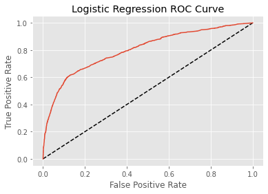

```python
#plotting the ROC curve
fpr,tpr, thresholds = roc_curve(y_test_smote, y_pred_probs_log)
plt.plot([0,1],[0,1],'k--')
plt.plot(fpr,tpr)
plt.xlabel('False Positive Rate')
plt.ylabel('True Positive Rate')
plt.title('Logistic Regression ROC Curve')
plt.show()
```

```python
print(roc_auc_score(y_test_smote, y_pred_probs_log))
#the auc value(area under curve) for the simplest logistic regression model is 0.80!
```

```
0.8018226169018983
```

```python
#logistic regression default on test data set
test_score_log_default = logreg.score(X_test_smote,y_test_smote)
print(test_score_log_default)
```

```
0.7432915102115578
```

```python
#Now, we are using grid search to tune the model

from sklearn.model_selection import RepeatedStratifiedKFold
from sklearn.model_selection import GridSearchCV
import time
start_time = time.time()

# define models and parameters
X, y = (X_train_smote, y_train_smote)
model = LogisticRegression()
solvers = ['newton-cg', 'lbfgs', 'liblinear']
penalty = ['l2']
c_values = [100, 10, 1.0, 0.1, 0.01]

# define grid search
grid = dict(solver=solvers,penalty=penalty,C=c_values)
cv = RepeatedStratifiedKFold(n_splits=10, n_repeats=3, random_state=1)
grid_search = GridSearchCV(estimator=model, param_grid=grid, n_jobs=-1, cv=cv, scoring='accuracy',error_score=0)
grid_result = grid_search.fit(X, y)

# summarize results
print("Best: %f using %s" % (grid_result.best_score_, grid_result.best_params_))
means = grid_result.cv_results_['mean_test_score']
stds = grid_result.cv_results_['std_test_score']
params = grid_result.cv_results_['params']
for mean, stdev, param in zip(means, stds, params):
    print("%f (%f) with: %r" % (mean, stdev, param))
print("Execution time: " + str((time.time() - start_time)) + ' ms')
```

```
Best: 0.739265 using {'C': 0.01, 'penalty': 'l2', 'solver': 'newton-cg'}
0.738524 (0.006537) with: {'C': 100, 'penalty': 'l2', 'solver': 'newton-cg'}
0.735030 (0.005794) with: {'C': 100, 'penalty': 'l2', 'solver': 'lbfgs'}
0.737736 (0.006112) with: {'C': 100, 'penalty': 'l2', 'solver': 'liblinear'}
0.738576 (0.006516) with: {'C': 10, 'penalty': 'l2', 'solver': 'newton-cg'}
0.734685 (0.006021) with: {'C': 10, 'penalty': 'l2', 'solver': 'lbfgs'}
0.737756 (0.006089) with: {'C': 10, 'penalty': 'l2', 'solver': 'liblinear'}
0.738660 (0.006567) with: {'C': 1.0, 'penalty': 'l2', 'solver': 'newton-cg'}
0.734601 (0.005841) with: {'C': 1.0, 'penalty': 'l2', 'solver': 'lbfgs'}
0.737626 (0.006121) with: {'C': 1.0, 'penalty': 'l2', 'solver': 'liblinear'}
0.738862 (0.006702) with: {'C': 0.1, 'penalty': 'l2', 'solver': 'newton-cg'}
0.734633 (0.005873) with: {'C': 0.1, 'penalty': 'l2', 'solver': 'lbfgs'}
0.737762 (0.006009) with: {'C': 0.1, 'penalty': 'l2', 'solver': 'liblinear'}
0.739265 (0.006696) with: {'C': 0.01, 'penalty': 'l2', 'solver': 'newton-cg'}
0.734991 (0.006220) with: {'C': 0.01, 'penalty': 'l2', 'solver': 'lbfgs'}
0.737203 (0.006220) with: {'C': 0.01, 'penalty': 'l2', 'solver': 'liblinear'}
Execution time: 235.12995743751526 ms
```

```python
#Evaluating on the test set
test_score_log = grid_search.score(X_test_smote,y_test_smote)
print(test_score_log) #this is even slightly better than our highest accuarcy score in training dataset
```

```
0.7421009249931313
```

```python
# See what the best_estimator_ property is
print((grid_search.best_estimator_))
```

```
LogisticRegression(C=0.01, solver='newton-cg')
```

```python
# Create an array of predictions directly using the best_estimator_ property
predictions = grid_search.best_estimator_.predict(X_test_smote)

# Take a look to confirm it worked, this should be an array of 1's and 0's
print(predictions[0:5])

# classfication report for the best logistic regression model
print(classification_report(y_test_smote,predictions))
```

```
[0 1 0 0 0]
              precision    recall  f1-score   support

           0       0.70      0.84      0.77     10919
           1       0.80      0.64      0.71     10919

    accuracy                           0.74     21838
   macro avg       0.75      0.74      0.74     21838
weighted avg       0.75      0.74      0.74     21838
```

```python
# Get the ROC-AUC score
predictions_proba = grid_search.best_estimator_.predict_proba(X_test_smote)[:,1]
print("ROC-AUC Score \n", roc_auc_score(y_test_smote, predictions_proba))
```

```
ROC-AUC Score
 0.8068314422227145
```

```python
#scaling our data
from sklearn.preprocessing import StandardScaler
scaler = StandardScaler()
X_train_scaled = scaler.fit_transform(X_train_smote)
X_test_scaled = scaler.fit_transform(X_test_smote)
print(np.mean(X_train_scaled), np.std(X_train_scaled))
print(X_test_scaled.shape)
print(y_test_smote)
```

```
-6.06261454873704e-16 1.0000000000000002
(21838, 24)
       y
0      0
1      0
2      1
3      0
4      0
...   ..
21833  1
21834  1
21835  1
21836  1
21837  1

[21838 rows x 1 columns]
```

```python
#try fitting logistic regression by using standardied data
logreg_scaled = LogisticRegression(C=100, solver='newton-cg',penalty ='l2')
logreg_scaled.fit(X_train_scaled, y_train_smote.values.ravel())
```

```
LogisticRegression(C=100, solver='newton-cg')
```

```python
#predictions and classfication report --does not see too much help
predictions_logreg_scaled = logreg_scaled.predict(X_test_scaled)
print(classification_report(y_test_smote,predictions_logreg_scaled))
```

```
              precision    recall  f1-score   support

           0       0.70      0.84      0.77     10919
           1       0.80      0.64      0.71     10919

    accuracy                           0.74     21838
   macro avg       0.75      0.74      0.74     21838
weighted avg       0.75      0.74      0.74     21838
```

```python
#Evaluating on the test set
test_score_log_scaled =logreg_scaled.score(X_test_scaled,y_test_smote)
print(test_score_log_scaled)
#this is weaker performance than our previous model--logistic regression with best hyperparameters
```

```
0.7417345910797692
```

```python
print(roc_auc_score(y_test_smote, predictions_logreg_scaled))
```

```
0.7417345910797692
```

# 6. Random Forest

- Fit random forest
- Tune Hyperparameters by using Grid search cross-validation;
- Refit the model;
- Model Performance;

```python
#fit random forest with n_estimators = 100
clf1 = RandomForestClassifier(n_estimators = 100)
clf1.fit(X_train_smote, y_train_smote.values.ravel())
y_pred_2 = clf1.predict(X_test_smote)
```

```python
y_pred_probs_random = clf1.predict_proba(X_test_smote)[:, 1]
print(y_pred_probs_random[0])
print(classification_report(y_test_smote,y_pred_2))
```

```
0.45988945654413776
              precision    recall  f1-score   support

           0       0.75      0.88      0.81     10919
           1       0.86      0.71      0.77     10919

    accuracy                           0.79     21838
   macro avg       0.80      0.79      0.79     21838
weighted avg       0.80      0.79      0.79     21838
```

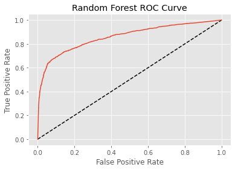

```python
#plotting the ROC curve
fpr,tpr, thresholds = roc_curve(y_test_smote, y_pred_probs_random)
plt.plot([0,1],[0,1],'k--')
plt.plot(fpr,tpr)
plt.xlabel('False Positive Rate')
plt.ylabel('True Positive Rate')
plt.title('Random Forest ROC Curve')
plt.show()
```

```python
print(roc_auc_score(y_test_smote, y_pred_probs_random))
```

```
0.8587855819406204
```

```python
#Evaluating on the test set
test_score_random_default =clf1.score(X_test_smote,y_test_smote)
print(test_score_random_default)
```

```
0.7941661324297097
```

```python
# define dataset
X, y = (X_train_smote, y_train_smote.values.ravel())

# define models and parameters
model = RandomForestClassifier()
n_estimators = [10, 100, 1000]
max_features = ['sqrt', 'log2']
start_time = time.time()

# define grid search
grid = dict(n_estimators=n_estimators,max_features=max_features)
cv = RepeatedStratifiedKFold(n_splits=10, n_repeats=3, random_state=1)
grid_search = GridSearchCV(estimator=model, param_grid=grid, n_jobs=-1, cv=cv, scoring='accuracy',error_score=0)
grid_result = grid_search.fit(X, y)

# summarize results
print("Best: %f using %s" % (grid_result.best_score_, grid_result.best_params_))
means = grid_result.cv_results_['mean_test_score']
stds = grid_result.cv_results_['std_test_score']
params = grid_result.cv_results_['params']
for mean, stdev, param in zip(means, stds, params):
    print("%f (%f) with: %r" % (mean, stdev, param))
print("Execution time: " + str((time.time() - start_time)) + ' ms')
```

```
Best: 0.812697 using {'max_features': 'log2', 'n_estimators': 1000}
0.811493 (0.004867) with: {'max_features': 'sqrt', 'n_estimators': 10}
0.812528 (0.005093) with: {'max_features': 'sqrt', 'n_estimators': 100}
0.812638 (0.004941) with: {'max_features': 'sqrt', 'n_estimators': 1000}
0.811623 (0.004646) with: {'max_features': 'log2', 'n_estimators': 10}
0.812463 (0.004972) with: {'max_features': 'log2', 'n_estimators': 100}
0.812697 (0.004675) with: {'max_features': 'log2', 'n_estimators': 1000}
Execution time: 422.9224863052368 ms
```

```python
#Evaluating on the test set
test_score_random = grid_search.score(X_test_smote,y_test_smote)
print(test_score_random)
```

```
0.7950361754739445
```

```python
# Create an array of predictions directly using the best_estimator_ property
predictions_2 = grid_search.best_estimator_.predict(X_test_smote)

# Take a look to confirm it worked, this should be an array of 1's and 0's
print(predictions_2[0:5])

# classfication report for the best logistic regression model
print(classification_report(y_test_smote,predictions_2))
```

```
[0 0 0 0 0]
              precision    recall  f1-score   support

           0       0.75      0.88      0.81     10919
           1       0.86      0.71      0.78     10919

    accuracy                           0.80     21838
   macro avg       0.80      0.80      0.79     21838
weighted avg       0.80      0.80      0.79     21838
```

```python
#roc-auc score for random forest with best hyperparameters
random_best = RandomForestClassifier(max_features = 'log2', n_estimators = 1000)
random_best.fit(X_train_smote, y_train_smote.values.ravel())
y_pred_random_best = random_best.predict(X_test_smote)
```

```python
y_pred_probs_random_best = random_best.predict_proba(X_test_smote)[:, 1]
print(y_pred_probs_random_best[0])
print(classification_report(y_test_smote,y_pred_random_best))
```

```
0.48254093537279996
              precision    recall  f1-score   support

           0       0.75      0.88      0.81     10919
           1       0.86      0.71      0.78     10919

    accuracy                           0.79     21838
   macro avg       0.80      0.79      0.79     21838
weighted avg       0.80      0.79      0.79     21838
```

```python
print(roc_auc_score(y_test_smote, y_pred_probs_random_best))
```

```
0.8594100547788975
```

# 7. KNN

- Fit KNN;
- Tune Hyperparameters by using Grid search cross-validation;
- Refit the model;
- Model Performance;
- Compare with the scaled KNN model;

```python
#fit knn by using n_neighbors = 100
knn = KNeighborsClassifier(n_neighbors = 100)
knn.fit(X_train_smote,y_train_smote.values.ravel())
prediction_3 = knn.predict(X_test_smote)
```

```python
# Score report
print(classification_report(y_test_smote,prediction_3))
```

```
              precision    recall  f1-score   support

           0       0.68      0.88      0.77     10919
           1       0.84      0.59      0.69     10919

    accuracy                           0.74     21838
   macro avg       0.76      0.74      0.73     21838
weighted avg       0.76      0.74      0.73     21838
```

```
0.28
```

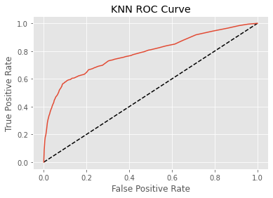

```python
y_pred_probs_knn = knn.predict_proba(X_test_smote)[:, 1]
print(y_pred_probs_knn[0])
#plotting the ROC curve
fpr,tpr, thresholds = roc_curve(y_test_smote, y_pred_probs_knn)
plt.plot([0,1],[0,1],'k--')
plt.plot(fpr,tpr)
plt.xlabel('False Positive Rate')
plt.ylabel('True Positive Rate')
plt.title('KNN ROC Curve')
plt.show()
```

```python
print(roc_auc_score(y_test_smote, prediction_3))
```

```
0.7383917941203406
```

```python
#Evaluating on the test set
test_score_knn_default = knn.score(X_test_smote,y_test_smote)
print(test_score_knn_default)
```

```
0.7383917941203407
```

```python
#Now, we are using grid search to tune the model
X, y = (X_train_smote, y_train_smote.values.ravel())

# define models and parameters
model = KNeighborsClassifier()
n_neighbors = range(1, 21, 2)
weights = ['uniform', 'distance']
metric = ['euclidean', 'manhattan', 'minkowski']
start_time = time.time()

# define grid search
grid = dict(n_neighbors=n_neighbors,weights=weights,metric=metric)
cv = RepeatedStratifiedKFold(n_splits=10, n_repeats=3, random_state=1)
grid_search = GridSearchCV(estimator=model, param_grid=grid, n_jobs=-1, cv=cv, scoring='accuracy',error_score=0)
grid_result = grid_search.fit(X, y)

# summarize results
print("Best: %f using %s" % (grid_result.best_score_, grid_result.best_params_))
means = grid_result.cv_results_['mean_test_score']
stds = grid_result.cv_results_['std_test_score']
params = grid_result.cv_results_['params']
for mean, stdev, param in zip(means, stds, params):
    print("%f (%f) with: %r" % (mean, stdev, param))
print("Execution time: " + str((time.time() - start_time)) + ' ms')
```

```
Best: 0.754639 using {'metric': 'euclidean', 'n_neighbors': 3, 'weights': 'distance'}
0.742766 (0.005208) with: {'metric': 'euclidean', 'n_neighbors': 1, 'weights': 'uniform'}
0.742766 (0.005208) with: {'metric': 'euclidean', 'n_neighbors': 1, 'weights': 'distance'}
0.749115 (0.005493) with: {'metric': 'euclidean', 'n_neighbors': 3, 'weights': 'uniform'}
0.754639 (0.005356) with: {'metric': 'euclidean', 'n_neighbors': 3, 'weights': 'distance'}
0.738465 (0.005567) with: {'metric': 'euclidean', 'n_neighbors': 5, 'weights': 'uniform'}
0.749376 (0.004998) with: {'metric': 'euclidean', 'n_neighbors': 5, 'weights': 'distance'}
0.737151 (0.005265) with: {'metric': 'euclidean', 'n_neighbors': 7, 'weights': 'uniform'}
0.750377 (0.004530) with: {'metric': 'euclidean', 'n_neighbors': 7, 'weights': 'distance'}
0.731979 (0.006221) with: {'metric': 'euclidean', 'n_neighbors': 9, 'weights': 'uniform'}
0.748191 (0.005423) with: {'metric': 'euclidean', 'n_neighbors': 9, 'weights': 'distance'}
0.729350 (0.005554) with: {'metric': 'euclidean', 'n_neighbors': 11, 'weights': 'uniform'}
0.747150 (0.005132) with: {'metric': 'euclidean', 'n_neighbors': 11, 'weights': 'distance'}
0.726690 (0.005861) with: {'metric': 'euclidean', 'n_neighbors': 13, 'weights': 'uniform'}
0.746318 (0.005813) with: {'metric': 'euclidean', 'n_neighbors': 13, 'weights': 'distance'}
0.727568 (0.006067) with: {'metric': 'euclidean', 'n_neighbors': 15, 'weights': 'uniform'}
0.748361 (0.006008) with: {'metric': 'euclidean', 'n_neighbors': 15, 'weights': 'distance'}
0.727633 (0.006500) with: {'metric': 'euclidean', 'n_neighbors': 17, 'weights': 'uniform'}
0.749310 (0.006195) with: {'metric': 'euclidean', 'n_neighbors': 17, 'weights': 'distance'}
0.728739 (0.006340) with: {'metric': 'euclidean', 'n_neighbors': 19, 'weights': 'uniform'}
0.750130 (0.005945) with: {'metric': 'euclidean', 'n_neighbors': 19, 'weights': 'distance'}
0.741055 (0.004618) with: {'metric': 'manhattan', 'n_neighbors': 1, 'weights': 'uniform'}
0.741055 (0.004618) with: {'metric': 'manhattan', 'n_neighbors': 1, 'weights': 'distance'}
0.749427 (0.005737) with: {'metric': 'manhattan', 'n_neighbors': 3, 'weights': 'uniform'}
0.754385 (0.005624) with: {'metric': 'manhattan', 'n_neighbors': 3, 'weights': 'distance'}
0.739291 (0.006103) with: {'metric': 'manhattan', 'n_neighbors': 5, 'weights': 'uniform'}
0.749720 (0.005458) with: {'metric': 'manhattan', 'n_neighbors': 5, 'weights': 'distance'}
0.737795 (0.005139) with: {'metric': 'manhattan', 'n_neighbors': 7, 'weights': 'uniform'}
0.750657 (0.004780) with: {'metric': 'manhattan', 'n_neighbors': 7, 'weights': 'distance'}
0.732662 (0.006111) with: {'metric': 'manhattan', 'n_neighbors': 9, 'weights': 'uniform'}
0.748328 (0.005780) with: {'metric': 'manhattan', 'n_neighbors': 9, 'weights': 'distance'}
0.729624 (0.005828) with: {'metric': 'manhattan', 'n_neighbors': 11, 'weights': 'uniform'}
0.746682 (0.005600) with: {'metric': 'manhattan', 'n_neighbors': 11, 'weights': 'distance'}
0.726995 (0.006034) with: {'metric': 'manhattan', 'n_neighbors': 13, 'weights': 'uniform'}
0.746077 (0.005827) with: {'metric': 'manhattan', 'n_neighbors': 13, 'weights': 'distance'}
0.727288 (0.006156) with: {'metric': 'manhattan', 'n_neighbors': 15, 'weights': 'uniform'}
0.747287 (0.005963) with: {'metric': 'manhattan', 'n_neighbors': 15, 'weights': 'distance'}
0.728179 (0.005858) with: {'metric': 'manhattan', 'n_neighbors': 17, 'weights': 'uniform'}
0.748679 (0.005972) with: {'metric': 'manhattan', 'n_neighbors': 17, 'weights': 'distance'}
0.729669 (0.005726) with: {'metric': 'manhattan', 'n_neighbors': 19, 'weights': 'uniform'}
0.749636 (0.005733) with: {'metric': 'manhattan', 'n_neighbors': 19, 'weights': 'distance'}
0.742766 (0.005208) with: {'metric': 'minkowski', 'n_neighbors': 1, 'weights': 'uniform'}
0.742766 (0.005208) with: {'metric': 'minkowski', 'n_neighbors': 1, 'weights': 'distance'}
0.749115 (0.005493) with: {'metric': 'minkowski', 'n_neighbors': 3, 'weights': 'uniform'}
0.754639 (0.005356) with: {'metric': 'minkowski', 'n_neighbors': 3, 'weights': 'distance'}
0.738465 (0.005567) with: {'metric': 'minkowski', 'n_neighbors': 5, 'weights': 'uniform'}
0.749376 (0.004998) with: {'metric': 'minkowski', 'n_neighbors': 5, 'weights': 'distance'}
0.737151 (0.005265) with: {'metric': 'minkowski', 'n_neighbors': 7, 'weights': 'uniform'}
0.750377 (0.004530) with: {'metric': 'minkowski', 'n_neighbors': 7, 'weights': 'distance'}
0.731979 (0.006221) with: {'metric': 'minkowski', 'n_neighbors': 9, 'weights': 'uniform'}
0.748191 (0.005423) with: {'metric': 'minkowski', 'n_neighbors': 9, 'weights': 'distance'}
0.729350 (0.005554) with: {'metric': 'minkowski', 'n_neighbors': 11, 'weights': 'uniform'}
0.747150 (0.005132) with: {'metric': 'minkowski', 'n_neighbors': 11, 'weights': 'distance'}
0.726690 (0.005861) with: {'metric': 'minkowski', 'n_neighbors': 13, 'weights': 'uniform'}
0.746318 (0.005813) with: {'metric': 'minkowski', 'n_neighbors': 13, 'weights': 'distance'}
0.727568 (0.006067) with: {'metric': 'minkowski', 'n_neighbors': 15, 'weights': 'uniform'}
0.748361 (0.006008) with: {'metric': 'minkowski', 'n_neighbors': 15, 'weights': 'distance'}
0.727633 (0.006500) with: {'metric': 'minkowski', 'n_neighbors': 17, 'weights': 'uniform'}
0.749310 (0.006195) with: {'metric': 'minkowski', 'n_neighbors': 17, 'weights': 'distance'}
0.728739 (0.006340) with: {'metric': 'minkowski', 'n_neighbors': 19, 'weights': 'uniform'}
0.750130 (0.005945) with: {'metric': 'minkowski', 'n_neighbors': 19, 'weights': 'distance'}
Execution time: 713.4415512084961 ms
```

```python
#Evaluating on the test set
test_score_knn = grid_search.score(X_test_smote,y_test_smote)
print(test_score_knn)
```

```
0.7042769484385017
```

```python
# Create an array of predictions directly using the best_estimator_ property
predictions_3 = grid_search.best_estimator_.predict(X_test_smote)

# Take a look to confirm it worked, this should be an array of 1's and 0's
print(predictions_3[0:5])

# classfication report for the best logistic regression model
print(classification_report(y_test_smote,predictions_3))
```

```
[0 0 0 0 0]
              precision    recall  f1-score   support

           0       0.64      0.93      0.76     10919
           1       0.87      0.48      0.62     10919

    accuracy                           0.70     21838
   macro avg       0.75      0.70      0.69     21838
weighted avg       0.75      0.70      0.69     21838
```

```python
#try fitting knn by using best hyperparameters
knn_best = KNeighborsClassifier(metric = 'euclidean', n_neighbors = 3, weights = 'distance')
knn_best.fit(X_train_smote, y_train_smote.values.ravel())
prediction_knn_best = knn_best.predict(X_test_smote)
```

```python
print(roc_auc_score(y_test_smote, prediction_knn_best))
```

```
0.7042769484385016
```

```python
#try fitting knn by using standardied data
knn_scaled = KNeighborsClassifier(metric = 'euclidean', n_neighbors = 3, weights = 'distance')
knn_scaled.fit(X_train_scaled, y_train_smote.values.ravel())
prediction_4 = knn_scaled.predict(X_test_scaled)
```

```python
# Score report
print(classification_report(y_test_smote,prediction_4))
print(roc_auc_score(y_test_smote, prediction_4))
```

```
              precision    recall  f1-score   support

           0       0.66      0.94      0.78     10919
           1       0.90      0.52      0.66     10919

    accuracy                           0.73     21838
   macro avg       0.78      0.73      0.72     21838
weighted avg       0.78      0.73      0.72     21838

0.7284549867203957
```

```python
#Evaluating on the test set
test_score_knn_scaled = knn_scaled.score(X_test_scaled,y_test_smote)
print(test_score_knn_scaled)
```

```
0.7284549867203957
```

# 8. Stochastic Gradient Boosting

- Fit Stochastic Gradient Boosting;
- Tune Hyperparameters by using Grid search cross-validation;
- Refit the model;
- Model Performance;

```python
#fitting stochastic gradient boosting
from sklearn.ensemble import GradientBoostingClassifier
clf2 = GradientBoostingClassifier(n_estimators=100)
clf2.fit(X_train_smote,y_train_smote.values.ravel())
prediction_4 = clf2.predict(X_test_smote)
```

```python
# Score report
print(classification_report(y_test_smote,prediction_4))
```

```
              precision    recall  f1-score   support

           0       0.78      0.89      0.83     10919
           1       0.87      0.76      0.81     10919

    accuracy                           0.82     21838
   macro avg       0.83      0.82      0.82     21838
weighted avg       0.83      0.82      0.82     21838
```

```
0.25399721896902233
```

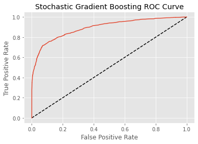

```python
y_pred_probs_stochastic = clf2.predict_proba(X_test_smote)[:, 1]
print(y_pred_probs_stochastic[0])
#plotting the ROC curve
fpr,tpr, thresholds = roc_curve(y_test_smote, y_pred_probs_stochastic)
plt.plot([0,1],[0,1],'k--')
plt.plot(fpr,tpr)
plt.xlabel('False Positive Rate')
plt.ylabel('True Positive Rate')
plt.title('Stochastic Gradient Boosting ROC Curve')
plt.show()
```

```python
print(roc_auc_score(y_test_smote, prediction_4))
```

```
0.8222364685410752
```

```python
#Evaluating on the test set
test_score_boosting_default = clf2.score(X_test_smote,y_test_smote)
print(test_score_boosting_default)
```

```
0.8222364685410752
```

```python
# define dataset
X, y = (X_train_smote, y_train_smote.values.ravel())

# define models and parameters
model = GradientBoostingClassifier()
n_estimators = [10, 100, 1000]
learning_rate = [0.001, 0.01, 0.1]
subsample = [0.5, 0.7, 1.0]
max_depth = [3, 7, 9]
start_time = time.time()
# define grid search
grid = dict(learning_rate=learning_rate, n_estimators=n_estimators, subsample=subsample, max_depth=max_depth)
cv = RepeatedStratifiedKFold(n_splits=10, n_repeats=3, random_state=1)
grid_search = GridSearchCV(estimator=model, param_grid=grid, n_jobs=-1, cv=cv, scoring='accuracy',error_score=0)
grid_result = grid_search.fit(X, y)

# summarize results
print("Best: %f using %s" % (grid_result.best_score_, grid_result.best_params_))
means = grid_result.cv_results_['mean_test_score']
stds = grid_result.cv_results_['std_test_score']
params = grid_result.cv_results_['params']
for mean, stdev, param in zip(means, stds, params):
    print("%f (%f) with: %r" % (mean, stdev, param))
print("Execution time: " + str((time.time() - start_time)) + ' ms')
```

```
Best: 0.815013 using {'learning_rate': 0.01, 'max_depth': 9, 'n_estimators': 1000, 'subsample': 0.5}
0.735830 (0.005833) with: {'learning_rate': 0.001, 'max_depth': 3, 'n_estimators': 10, 'subsample': 0.5}
0.735323 (0.005493) with: {'learning_rate': 0.001, 'max_depth': 3, 'n_estimators': 10, 'subsample': 0.7}
0.734959 (0.005587) with: {'learning_rate': 0.001, 'max_depth': 3, 'n_estimators': 10, 'subsample': 1.0}
0.736552 (0.005937) with: {'learning_rate': 0.001, 'max_depth': 3, 'n_estimators': 100, 'subsample': 0.5}
0.735973 (0.005518) with: {'learning_rate': 0.001, 'max_depth': 3, 'n_estimators': 100, 'subsample': 0.7}
0.734965 (0.005590) with: {'learning_rate': 0.001, 'max_depth': 3, 'n_estimators': 100, 'subsample': 1.0}
0.739799 (0.006064) with: {'learning_rate': 0.001, 'max_depth': 3, 'n_estimators': 1000, 'subsample': 0.5}
0.739740 (0.006006) with: {'learning_rate': 0.001, 'max_depth': 3, 'n_estimators': 1000, 'subsample': 0.7}
0.739083 (0.005862) with: {'learning_rate': 0.001, 'max_depth': 3, 'n_estimators': 1000, 'subsample': 1.0}
0.769505 (0.006597) with: {'learning_rate': 0.001, 'max_depth': 7, 'n_estimators': 10, 'subsample': 0.5}
0.768509 (0.006678) with: {'learning_rate': 0.001, 'max_depth': 7, 'n_estimators': 10, 'subsample': 0.7}
0.759544 (0.006532) with: {'learning_rate': 0.001, 'max_depth': 7, 'n_estimators': 10, 'subsample': 1.0}
0.770799 (0.006669) with: {'learning_rate': 0.001, 'max_depth': 7, 'n_estimators': 100, 'subsample': 0.5}
0.769056 (0.006117) with: {'learning_rate': 0.001, 'max_depth': 7, 'n_estimators': 100, 'subsample': 0.7}
0.763077 (0.008047) with: {'learning_rate': 0.001, 'max_depth': 7, 'n_estimators': 100, 'subsample': 1.0}
0.777162 (0.006309) with: {'learning_rate': 0.001, 'max_depth': 7, 'n_estimators': 1000, 'subsample': 0.5}
0.776576 (0.006042) with: {'learning_rate': 0.001, 'max_depth': 7, 'n_estimators': 1000, 'subsample': 0.7}
0.775034 (0.006202) with: {'learning_rate': 0.001, 'max_depth': 7, 'n_estimators': 1000, 'subsample': 1.0}
0.780330 (0.006166) with: {'learning_rate': 0.001, 'max_depth': 9, 'n_estimators': 10, 'subsample': 0.5}
0.779010 (0.006424) with: {'learning_rate': 0.001, 'max_depth': 9, 'n_estimators': 10, 'subsample': 0.7}
0.772465 (0.005495) with: {'learning_rate': 0.001, 'max_depth': 9, 'n_estimators': 10, 'subsample': 1.0}
0.781306 (0.006121) with: {'learning_rate': 0.001, 'max_depth': 9, 'n_estimators': 100, 'subsample': 0.5}
0.780324 (0.006070) with: {'learning_rate': 0.001, 'max_depth': 9, 'n_estimators': 100, 'subsample': 0.7}
0.775353 (0.006185) with: {'learning_rate': 0.001, 'max_depth': 9, 'n_estimators': 100, 'subsample': 1.0}
0.790050 (0.005752) with: {'learning_rate': 0.001, 'max_depth': 9, 'n_estimators': 1000, 'subsample': 0.5}
0.787415 (0.006074) with: {'learning_rate': 0.001, 'max_depth': 9, 'n_estimators': 1000, 'subsample': 0.7}
0.784657 (0.005647) with: {'learning_rate': 0.001, 'max_depth': 9, 'n_estimators': 1000, 'subsample': 1.0}
0.736182 (0.005749) with: {'learning_rate': 0.01, 'max_depth': 3, 'n_estimators': 10, 'subsample': 0.5}
0.735642 (0.005582) with: {'learning_rate': 0.01, 'max_depth': 3, 'n_estimators': 10, 'subsample': 0.7}
0.734965 (0.005590) with: {'learning_rate': 0.01, 'max_depth': 3, 'n_estimators': 10, 'subsample': 1.0}
0.739448 (0.005718) with: {'learning_rate': 0.01, 'max_depth': 3, 'n_estimators': 100, 'subsample': 0.5}
0.739753 (0.006234) with: {'learning_rate': 0.01, 'max_depth': 3, 'n_estimators': 100, 'subsample': 0.7}
0.739070 (0.005853) with: {'learning_rate': 0.01, 'max_depth': 3, 'n_estimators': 100, 'subsample': 1.0}
0.798950 (0.005466) with: {'learning_rate': 0.01, 'max_depth': 3, 'n_estimators': 1000, 'subsample': 0.5}
0.798345 (0.005193) with: {'learning_rate': 0.01, 'max_depth': 3, 'n_estimators': 1000, 'subsample': 0.7}
0.797857 (0.005195) with: {'learning_rate': 0.01, 'max_depth': 3, 'n_estimators': 1000, 'subsample': 1.0}
0.769368 (0.005927) with: {'learning_rate': 0.01, 'max_depth': 7, 'n_estimators': 10, 'subsample': 0.5}
0.769056 (0.006446) with: {'learning_rate': 0.01, 'max_depth': 7, 'n_estimators': 10, 'subsample': 0.7}
0.762960 (0.008025) with: {'learning_rate': 0.01, 'max_depth': 7, 'n_estimators': 10, 'subsample': 1.0}
```

[output cut: 28 more lines]

```
0.810999 (0.004583) with: {'learning_rate': 0.1, 'max_depth': 7, 'n_estimators': 100, 'subsample': 0.7}
0.809665 (0.004627) with: {'learning_rate': 0.1, 'max_depth': 7, 'n_estimators': 100, 'subsample': 1.0}
0.813887 (0.004936) with: {'learning_rate': 0.1, 'max_depth': 7, 'n_estimators': 1000, 'subsample': 0.5}
0.814089 (0.004721) with: {'learning_rate': 0.1, 'max_depth': 7, 'n_estimators': 1000, 'subsample': 0.7}
0.814044 (0.004945) with: {'learning_rate': 0.1, 'max_depth': 7, 'n_estimators': 1000, 'subsample': 1.0}
0.789653 (0.005824) with: {'learning_rate': 0.1, 'max_depth': 9, 'n_estimators': 10, 'subsample': 0.5}
0.787747 (0.006430) with: {'learning_rate': 0.1, 'max_depth': 9, 'n_estimators': 10, 'subsample': 0.7}
0.785281 (0.005722) with: {'learning_rate': 0.1, 'max_depth': 9, 'n_estimators': 10, 'subsample': 1.0}
0.814707 (0.005076) with: {'learning_rate': 0.1, 'max_depth': 9, 'n_estimators': 100, 'subsample': 0.5}
0.814733 (0.004828) with: {'learning_rate': 0.1, 'max_depth': 9, 'n_estimators': 100, 'subsample': 0.7}
0.813829 (0.004905) with: {'learning_rate': 0.1, 'max_depth': 9, 'n_estimators': 100, 'subsample': 1.0}
0.813874 (0.004794) with: {'learning_rate': 0.1, 'max_depth': 9, 'n_estimators': 1000, 'subsample': 0.5}
0.813979 (0.005169) with: {'learning_rate': 0.1, 'max_depth': 9, 'n_estimators': 1000, 'subsample': 0.7}
0.814414 (0.005239) with: {'learning_rate': 0.1, 'max_depth': 9, 'n_estimators': 1000, 'subsample': 1.0}
Execution time: 10706.046788454056 ms
```

```python
#Evaluating on the test set
test_score_boosting = grid_search.score(X_test_smote,y_test_smote)
print(test_score_boosting)
```

```
0.8131697041853649
```

```python
#fitting models with the best hyperparameters and get the roc score
boosting_best = GradientBoostingClassifier(learning_rate = 0.01, max_depth = 9, n_estimators = 1000, subsample = 0.5)
boosting_best.fit(X_train_smote,y_train_smote.values.ravel())
prediction_5 = boosting_best.predict(X_test_smote)
```

```python
print(roc_auc_score(y_test_smote, prediction_5))
```

```
0.8147724150563238
```

# 9. Model Evaluation

- K fold cross validation score for each model
- Comparing feature importance

```python
from sklearn.model_selection import KFold
from sklearn.model_selection import cross_val_score
# Build the k-fold cross-validator
kfold = KFold(n_splits=3, random_state=42,shuffle=True)
#mean score for logi_1
result_logi_1 = cross_val_score(logreg,X_train_smote, y_train_smote.values.ravel(),cv=kfold, scoring='accuracy')
print(result_log_1.mean())
```

[output not shown]

```python
#mean score for logi_scaled
result_log_2 = cross_val_score(logreg_scaled,X_train_scaled, y_train_smote.values.ravel(),cv=kfold, scoring='accuracy')
print(result_log_2.mean())
```

```
0.7384651994010607
```

```python
#mean score for random forest default
result_random_1 = cross_val_score(clf1,X_train_smote,y_train_smote.values.ravel(),cv=kfold, scoring='accuracy')
print(result_random_1.mean())
```

```
0.8085916025536197
```

```python
#mean score for knn default
result_knn_1 = cross_val_score(knn,X_train_smote,y_train_smote.values.ravel(),cv=kfold, scoring='accuracy')
print(result_knn_1.mean())
```

```
0.7422516296856753
```

```python
#mean score for knn scaled
result_knn_scaled = cross_val_score(knn_scaled,X_train_scaled, y_train_smote.values.ravel(),cv=kfold, scoring='accuracy')
print(result_knn_scaled.mean())
```

```
0.7493167507580459
```

```python
#mean score for Stochastic Gradient Boosting default
result_stochastic = cross_val_score(clf2,X_train_smote,y_train_smote.values.ravel(),cv=kfold, scoring='accuracy')
print(result_stochastic.mean())
```

```
0.7978569403634491
```

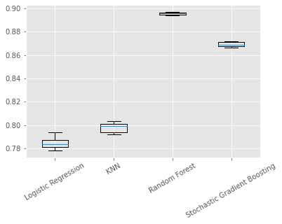

```python
#Model Comparsion: default model performance with unscaled data
models = {"Logistic Regression": LogisticRegression(),"KNN": KNeighborsClassifier(n_neighbors = 100),
          "Random Forest":  RandomForestClassifier(n_estimators = 100),
          "Stochastic Gradient Boosting": GradientBoostingClassifier(n_estimators=100)}
results = []
for model in models.values():
    kf = KFold(n_splits=6, random_state=42, shuffle=True)
    cv_results = cross_val_score(model, X_train_smote,y_train_smote.values.ravel(),
                                 cv=kf, scoring = 'roc_auc')
    results.append(cv_results)
plt.boxplot(results, labels=models.keys())
plt.xticks(rotation=30)
plt.show()
```

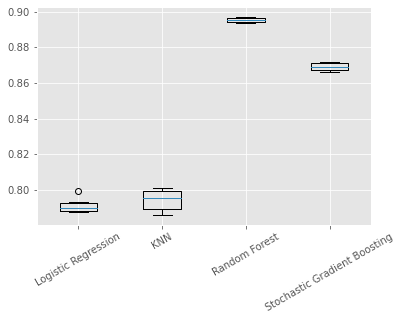

```
[array([0.7888396 , 0.78828245, 0.79326452, 0.78779001, 0.79047019,
       0.79956722]), array([0.79805888, 0.78613775, 0.80125226, 0.79246604, 0.7885801 ,
       0.80008661]), array([0.89416534, 0.89344412, 0.89704435, 0.89613987, 0.8945006 ,
       0.89646137]), array([0.86751641, 0.86620351, 0.87146722, 0.87030593, 0.86759092,
       0.87178729])]
```

```python
#Model Comparsion: default model performance with scaled data
models = {"Logistic Regression": LogisticRegression(),"KNN": KNeighborsClassifier(n_neighbors = 100),
          "Random Forest":  RandomForestClassifier(n_estimators = 100),
          "Stochastic Gradient Boosting": GradientBoostingClassifier(n_estimators=100)}
results = []
for model in models.values():
    kf = KFold(n_splits=6, random_state=42, shuffle=True)
    cv_results = cross_val_score(model, X_train_scaled,y_train_smote.values.ravel(),
                                 cv=kf,scoring = 'roc_auc')
    results.append(cv_results)
plt.boxplot(results, labels=models.keys())
plt.xticks(rotation=30)
plt.show()
print(results)
```